# Ground-based spectrometry calculations for the Ocean Optics USB2000

Edward P. Morris, UCA

2016-04-26

This is an example of the data processing of ground-based Ocean Optics USB2000 (OO-USB2000) spectroradiometer measurements.

Calculations have been documented in an R package to improve reproducibility.

Fist we need to load the R package, as it is not on CRAN it needs to be downloaded from GitHub, this can be done directly with the package `devtools`.

```r
#install.packages("devtools")

#library(devtools)

#install_github("edwardpmorris/FASTSpectra")

library(FASTSpectra)
```

Details about each of the functions are now available via R help, for example by typing `help("FASTspectra")` in the console. `FASTSpectra` essentially uses `hyperSpec` as a framework for parsing, calibrating and other performing other operations on spectral data.

## A working example

A number of ground-based, paired ‘sample’ and ‘reference’ spectra of different ground types (concrete path, green-lawn and brown-lawn) were collected during an instrument inter-comparison conducted at Field Spectrometry Facility (FSF), Edinburugh.

The spectra collected with the OO-USB2000 are installed with the package, to use them we need to set the file path.

```r
file.path <- system.file("extdata", package = "FASTSpectra")
```

Then we can parse the spectra into `hyperSpec` object using the function specific for reading OO text files.

```r
dn <- FASTSpectra::read.txt.OceanOptics(files=paste0(file.path,"/*.txt"))
```

Details about the `hyperSpec` object can be accessed with by typing the object name in the console, `dn`. If you do this you will see there are 44 spectra with a wavelength range between 339.47 to 1028.84 nm and 2048 data points per spectra. Metadata associated with each spectra is also included as a dataframe with 15 columns, including information such as the filename, integration-time and timestamp of the measurement.

We can also access all of the `hyperSpec` functions, especially designed for working with spectral data, for example plotting.

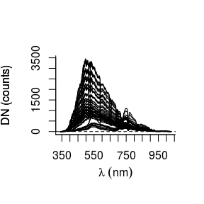

```r
library(hyperSpec)

hyperSpec::plotspc(dn)
```

Looking at the plot we can see a mix of spectra with high and low values in the mid wavelengths (~550 nm), that is because the ‘sample’ (S) and ‘reference’ (R) measurements are all in one file.

Which is which is defined in a ‘field log’, a `.csv` file with columns id, S, and R, we can assign a column in the metadata using the `FASTSpectra::assign.type` function:

```r
# assign measurement id and type using fieldlog file
logfile <- paste0(file.path,"/fieldlog.csv")

dn <- FASTSpectra::assign.type(dn, logfile=logfile)
```

Now if we check the metadata (type `dn` in console) we will see 2 new columns, type and id. These can be used to split the `hyperSpec` object into sample and reference spectra.

```r
# split into sample and reference spectra
dn <- hyperSpec::split(x=dn, f=dn@data$type)
```

### Radiometric calibration

Spectra, as instrument values, called digital number (DN) counts, require conversion to [radiometric units](https://en.wikipedia.org/wiki/Template:SI_radiometry_units) using instrument specific metadata and calibration values (instrument response functions). For this we use the `FASTSpectra::rad.cor` function, which allows the calculation of normalised DN, radiant energy, spectral flux, spectral intensity, spectral radiance and spectral irradiance.

These only make sense if the ‘measurement geometry’, ‘integration time’ [s] of a measurement, ‘surface area of the instrument light apature’ [m], and ‘instrument-specific response function’ in radiant energy (e.g., J/count or other units) is known and supplied to the function.

Luckily, with help from FSF with have all of these, and can go ahead and calculate the spectral irradiance [W / m2 nm] of the sample spectra.

```r
# set path of instrument-specific response function
cal.rad <- paste0(file.path,"/*.IrradCal")

# convert [DN/nm] to [W / m2 nm]
sam <- rad.corr(dn$SAMP,
                type="spectral.irradiance",
                cal.DN2RadiantEnergy = cal.rad
                )
```

### Reference panel

We can also do the same for the reference measurements, however for these we also need to include the reference panel calibration i.e., the reflectance of the reference panel relative to a ‘lambertian’ surface with a reflectance factor of 1 throughout the wavelength range of interest.

```r
# convert [DN/nm] to [W / m2 nm] relative to lambertian reference panel
cal.ref <- paste0(file.path,"/*.ReflCal")

ref <- rad.corr(dn$REF,
                type="spectral.irradiance",
                is.REF=TRUE,
                cal.DN2RadiantEnergy = cal.rad,
                cal.RRefPanel = cal.ref
                )
```

We can no plot each set of spectra and observe that indeed the reference measurements are generally much higher than the samples.

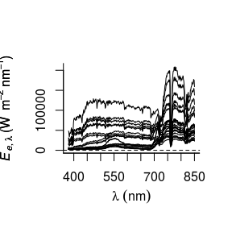

```r
plot(sam, wl.range=380:850)
```

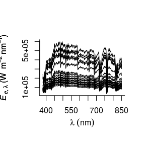

```r
plot(ref, wl.range=380:850)
```

### Reflectance

Now that our spectra are calibrated we can go ahead and calculate the ‘absolute’ reflectance for each specta pair (defined by the logfile).

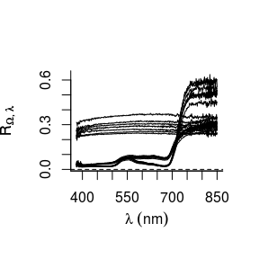

```r
# calculate reflectance as 'irradiance/irradiance'
SHR <- calc.reflectance(reference=ref, sample=sam, logfile=logfile)

# plot absolute reflectance
plot(SHR, wl.range=380:850)
```

In this plot of absolute or ‘hemispherical-conical’ reflectance the groupings of the spectra from measurements at the same positions on the 3 ground types becomes a bit clearer. Around 7 spectra were collected in a ‘round-robin’ fashion, i.e., one ground type and then the next, in variable lighting conditions (it was summer in Scotland).

To get a feeling for the variability in the measured reflectance spectra we can group the spectra by ground type and calculate quartiles.

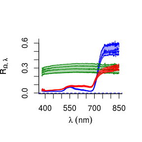

```r
# calculate quartiles by ground type
SHR.quant <-
  aggregate(
  SHR,
  SHR@data$id,
  quantile,
  probs = c(0.05, 0.16, 0.5, 0.84, 0.95),
  na.rm = T
  )

plot(SHR.quant
  , col = matlab.dark.palette(length(unique(
  SHR.quant@data$.aggregate
  )))
  , fill=SHR.quant@data$.aggregate
  , wl.range = 380:850)
```

## Radiometric calculations in detail

### Normalised Digital Number counts (*DN*<sub>norm</sub>) [counts s<sup>-1</sup> nm<sup>-1</sup>]

Calculations begin with conversion of instrument counts spectra (*DN*<sub>$\lambda$</sub>) to normalised DN (*DN*<sub>norm,$\lambda$</sub>, counts s<sup>-1</sup> nm<sup>-1</sup>) using the ‘integration time’ (*t*, s) i.e., the time period over which the instrument records light through the measuring apature, and the ‘wavelength spread’ i.e., the width of each band (d<sub>$\lambda$</sub>, nm).

$$DN_{\mathrm{norm, \lambda}} = \frac{DN_{\lambda}}{t \times d_{\lambda}}$$

These only make sense if the ‘measurement geometry’, ‘integration time’ [s] of a measurement, ‘surface area of the instrument light apature’ [m], and ‘instrument-specific response function’ in radiant energy (e.g., J/count or other units) is known and supplied to the function.

### Radiant energy (Q) [J]

If a ‘instrument-specific response function’ (*IRF*<sub>$\lambda$</sub>, J s nm count<sup>-1</sup>) is available, radiant energy is calculated as:

$$Q_{\mathrm{e}} = {DN_{\mathrm{norm, \lambda}}}\times{IRF_{\lambda}}$$

### Spectral flux (Φe,λ) [W / nm]

If a ‘instrument-specific response function’ (*IRF*<sub>$\lambda$</sub>, J count<sup>-1</sup>) is available, spectral flux is calculated as:

$$\Phi_{\mathrm{e, \lambda}} = {DN_{\mathrm{norm, \lambda}}}\times{IRF_{\lambda}}$$

### Spectral intensity (I<sub>e,Ω,λ</sub>) [W sr<sup>-1</sup> nm<sup>-1</sup>]

Using the ‘solid angle of the collector’ in steradians (Ω, sr) spectral intensity can be calculated as:

$$I_{\mathrm{e},\Omega, \lambda} = \frac{ \Phi_\mathrm{e, \lambda}}{ \Omega}$$

### Spectral radiance [ W / sr m2 nm]

Using the ‘projected area of the collector’ (*A*cos$\theta$),

$$L_{\mathrm{e},\Omega, \lambda} = \frac{ I_{\mathrm{e},\Omega, \lambda}}{ A \cos \theta}$$